# Hutterite iPSC Panel QC

Courtney Kagan

Last updated: 2015-04-09

This is the workflow used for QC and initial expression data analysis on the 73 Hutterite iPSC samples.

# Hutterite iPSC Expression QC

## Normalization

First we quantile normalize the data using the lumi package in R.

```r
###### NORMALIZATION: log2 stabilized and quantile normalization ###################
data.norm.all <- lumiExpresso(data.lumi.clean, bg.correct=TRUE, bgcorrect.param=list(method='forcePositive'), variance.stabilize=TRUE, varianceStabilize.param = list(method="log2"), normalize=TRUE, normalize.param=list(method="quantile"), QC.evaluation=TRUE, QC.param=list(), verbose=TRUE)
```

```
## Background Correction: forcePositive
## Variance Stabilizing Transform method: log2
## Normalization method: quantile
##
##
## Background correction ...
## done.
##
## Variance stabilizing ...
## Perform log2 transformation ...
## done.
##
## Normalizing ...
## Perform quantile normalization ...
## done.
##
## Quality control after preprocessing ...
## Perform Quality Control assessment of the LumiBatch object ...
## done.
```

## QC

Start with looking at things Pre- and Post-Normalization.

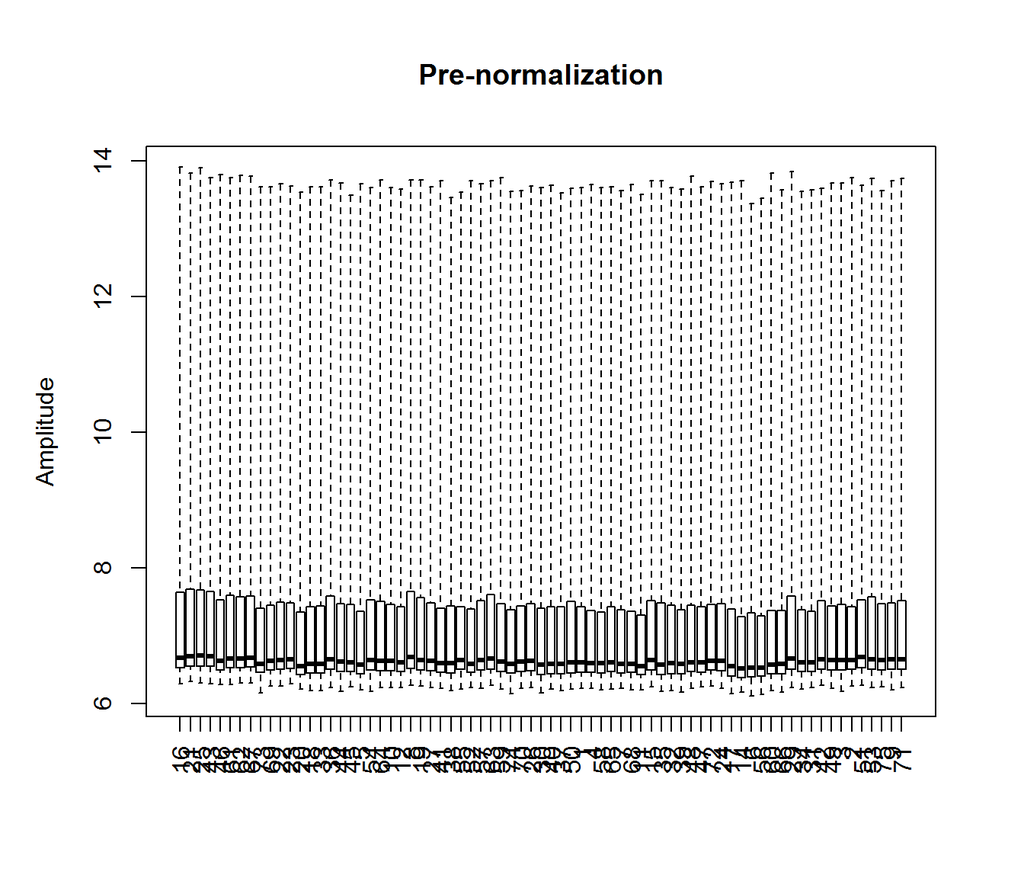

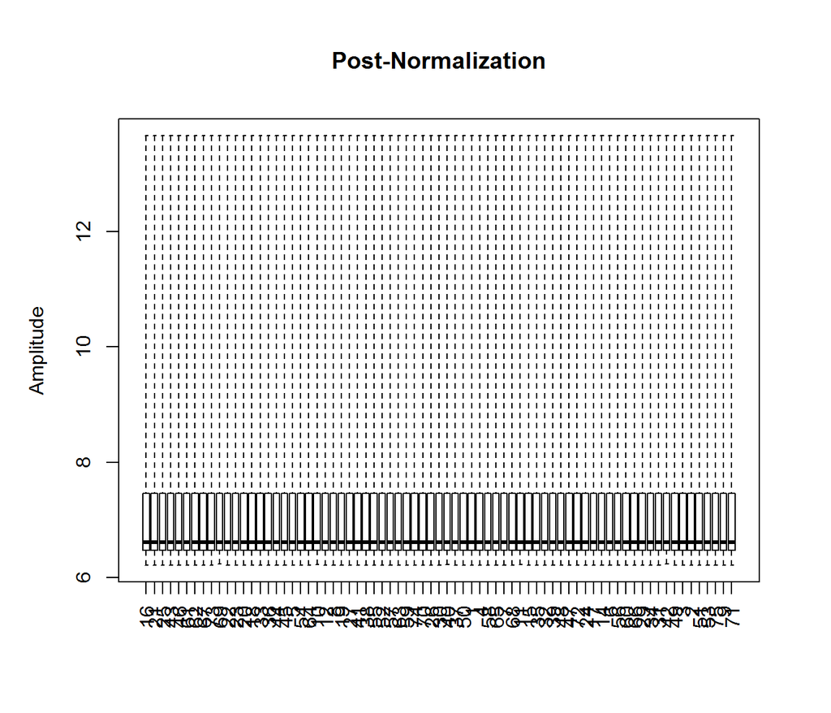

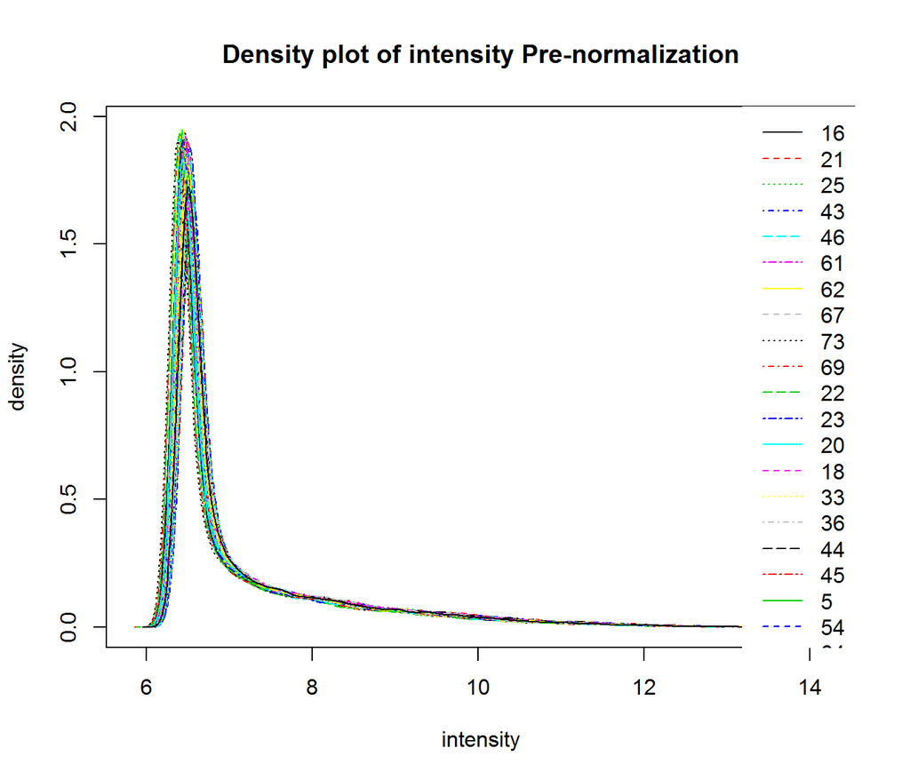

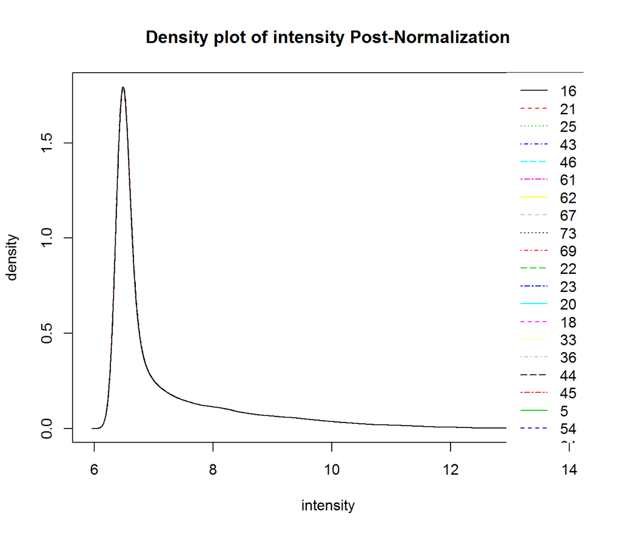

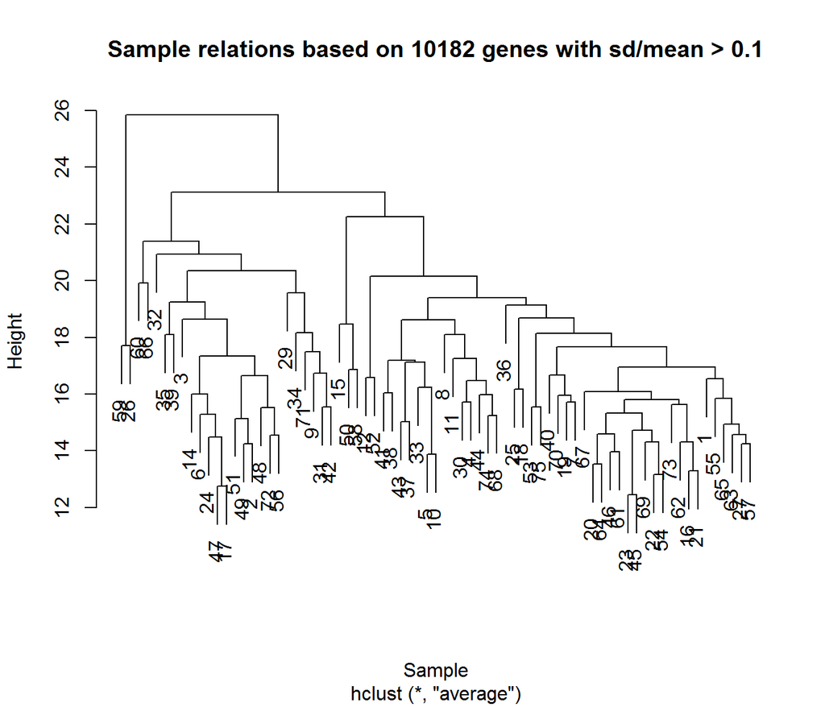

We see that the normalized data looks as expected.

## Conversion to Gene

Next we converted the probes to genes. And found that we have 10,950 unique genes represented.

```r
######## Converting probes to gene #################
## Finding the unique gene names matching probes to gene names using the good probe list
gene_names=c()
for(i in 1:dim(expr_quant.all)[1]){
  gene_names=c(gene_names,as.vector(goodprobes[as.vector(goodprobes$probeID)==row.names(expr_quant.all)[i],8]))
}

symbolsUniq = unique(gene_names)
length(symbolsUniq)
```

```
## [1] 10950
```

```r
# 10,950 have gene names


## This loop will give the most 3' value for multiple probes within the same gene. In the end you get a simple file with all genes that are expressed with the corresponding mean intensity expression levels across its different probes.
expr_gene = matrix(NA, ncol=73, nrow=length(unique(gene_names)))
i=0
for(gene in unique(gene_names)){
  i = i+1

  currRows = which(gene_names == gene)
  if(length(currRows)>1){
    if(goodprobes[currRows[1],6]=="+"){
      keepRow = currRows[which.max(goodprobes[currRows,2])]
    }
    else{
      keepRow = currRows[which.min(goodprobes[currRows,2])]
    }
  }
  else{
    keepRow=currRows[1]
  }
  expr_gene[i,] = expr_quant.all[keepRow,]

}
dim(expr_gene)
```

```
## [1] 10950    73
```

```r
#10950 73
rownames(expr_gene) = unique(gene_names)
colnames(expr_gene) = colnames(expr_quant.all)
#colnames(expr_gene) =samplenames$Name
##One gene is labeled "NA" and therefore also has no data attached
#which(is.na(row.names(expr_gene)))
#Row 4110 is NA
#expr_gene_new = na.omit(expr_gene)
#dim(expr_gene_new)
# 10949    73
#expr_gene = expr_gene_new

#write.table(expr_gene, 'OriginGeneExpression_Normalized.txt', sep='\t', row.names=T, quote=F)
```

Start from Data

expr_gene = read.table(‘OriginGeneExpression_Normalized.txt’, header=T, as.is=T, sep=‘’, row.names=1) samplenames = read.table(‘Covars.txt’, header=T, sep =‘’) #Re-order samplenames based on array location samplenames = samplenames[order(samplenames$Order),]

hearts = c(56:60,67:72) samplenames = samplenames[-hearts,] colnames(expr_gene) = samplenames$Sample goodprobes= read.table(‘ht12_probes_snps_ceu_hg19_af_0.05_map_37.txt’, header=T, sep=‘’)

## Create expression table for GEMMA

expr_gene_new = t(expr_gene) ## Re-order by individual in excel write.table(expr_gene_new, ‘OriginGeneExpression_Normalized_GEMMA.txt’, sep=‘’, row.names=T, quote=F)

Data Analysis

##### Generate chr and gene list for later filtering

# Generate the chr file to get autosomes only

# Create probe info list with chr, probe, and gene column

probeinfolist = cbind(goodprobes$chr, as.character(goodprobes[,4]),as.character(goodprobes[,8])) #Create lists of actual probes and genes from the data #probelist = rownames(expr_quant.all) genelist = rownames(expr_gene) #probelist = as.matrix(probelist) genelist = as.matrix(genelist) #colnames(probelist) = c("ILMN") colnames(genelist) = c("GeneID") colnames(probeinfolist) = c("Chr", "Probe", "Gene") #Merge actual list with reference information from good probe document #chrlist.probe = merge(probelist, probeinfolist, by.x = "ILMN", by.y = "Probe", all.x = T, all.y = F, sort=F) chrlist.gene = merge(genelist, probeinfolist, by.x = "GeneID", by.y = "Gene", all.x = T, all.y = F, sort=F) clean.chrlist.gene = chrlist.gene[!duplicated(chrlist.gene$GeneID), ] #To check for NAs which(is.na(clean.chrlist.gene)) #Generate final lists #chrfinal.p = as.matrix(chrlist.probe[,2]) chrfinal.g = as.matrix(clean.chrlist.gene[,2]) table(chrfinal.g) #Only 1-24 represented # 1 10 11 12 13 14 15 16 17 18 19 2 20 21 22 23 24 3 4 5 6 7 8 9 # 1141 162 782 702 316 125 275 615 412 489 549 405 489 379 415 422 14 647 576 187 355 354 476 662 xchr = clean.chrlist.gene[which(clean.chrlist.gene$Chr ==23 ),] #422 X chr genes ychr = clean.chrlist.gene[which(clean.chrlist.gene$Chr ==24 ),] #14 Y chr genes hist(as.numeric(chrfinal.g), breaks = 24, xlim = c(1,24)) sexgenes = c(which(clean.chrlist.gene$Chr == 23 ), which(clean.chrlist.gene$Chr ==24 )) expr_gene_nosex = expr_gene[-sexgenes,] # 10,513 genes on autosomes only

# variance by gene

variance.iPSC = apply(expr_gene,1,var) #variance.Heart = apply(expr_gene[,grep (“HT14”, colnames(expr_gene))],1,var)

# 0.2380351

mean(variance.iPSC) # 0.02569707

# variance.all = cbind(variance.iPSC, variance.Heart)

# boxplot(variance.all)

write.table(variance.iPSC, ‘Variance.txt’, quote=F, sep=‘’) #var.test(variance.Heart, variance.iPSC)

library(ggplot2) var_all <- data.frame(var=c(variance.iPSC), type = rep(“iPSC”), times=c(length(variance.iPSC))) ggplot(var_all, aes(x=var, fill=type)) + geom_density(alpha=0.09) +xlim(-.01,.25)+xlab(“Variance”) + ggtitle(“Gene Expression: Total variance”) + theme(legend.position=c(.75,.75)) +theme(text = element_text(size=23))

##### Read in data for dendograms and PCA

# Make labels and colors for the data

labs = samplenames$Sample

library(ClassDiscovery) #### Create dendograms with all genes ########## pdf(file = “Dendrograms.pdf”) euc = hclust(dist(t(expr_gene))) plotColoredClusters(euc, labs, cols = ‘black’, cex = .6,lwd =3, lty = 1,main = “Euclidean Distance”, line = -1, xlab=“”, sub=“”, col.main = “#45ADA8”)

# Make dendograms using pearson

pears = hclust(as.dist(1-cor(as.matrix(expr_gene)))) plotColoredClusters(pears, labs, cols = ‘black’, cex = .6,lwd = 3, lty = 1,main = “Pearson Correlation”, line = -1, xlab=“”, sub=“”, col.main = “#45ADA8”) dev.off()

###### Create dendograms of autosomes only and 1k most variable - only iPSCs

# Create expr data set of 1k most variable genes

var.ipsc = as.matrix(variance.iPSC) var_1k = as.matrix(var.ipsc[order(var.ipsc, decreasing = T),]) var1k = as.matrix(var_1k[1:1000,]) cols = samplenames$Batch

expr_gene = var1k

pdf(file = “Dendrograms_nosex_1k.pdf”) euc = hclust(dist(t(expr_gene[,grep (“LCL|Fib” , colnames(expr_gene), invert = T)]))) plotColoredClusters(euc, labs, cols, cex = 1,lwd = 3, lty = 1,main = “Euclidean Distance”, line = -1, xlab=“”, sub=“”) #Make dendograms using pearson pears = hclust(as.dist(1-cor(as.matrix(expr_gene)))) plotColoredClusters(pears, labs, cols, cex = 1,lwd = 3, lty = 1,main = “Pearson Correlation”, line = -1, xlab=“”, sub=“”) dev.off()

Create dendograms of autosomes only

pdf(file = “Dendrograms_nosex.pdf”) euc = hclust(dist(t(expr_gene_nosex))) plotColoredClusters(euc, labs, cols, cex = 1,lwd = 3, lty = 1,main = “Euclidean Distance”, line = -1, xlab=“”, sub=“”, col.main = “#45ADA8”) #Make dendograms using pearson pears = hclust(as.dist(1-cor(as.matrix(expr_gene_nosex)))) plotColoredClusters(pears, labs, cols, cex = 1,lwd = 3, lty = 1,main = “Pearson Correlation”, line = -1, xlab=“”, sub=“”, col.main = “#45ADA8”) dev.off()

Make heatmap of the data

pdf(file=“Heatmaps.pdf”) library(gplots) heatmap.2(cor(as.matrix(expr_gene), use = “complete”), margins=c(7,8),trace=“none”,main=“Gene Expression Correlation”, key=T, keysize=1.5,density.info=“none”,cexCol=0.9) heatmap.2(cor(as.matrix(expr_gene_nosex), use = “complete”), margins=c(7,8),trace=“none”,main=“Gene Expression Correlation Without X”, key=T, keysize=1.5,density.info=“none”,cexCol=0.9) dev.off()

PCA

## All the data

x.pca = prcomp(na.omit(t(expr_gene)), center = T,scale=T) x.pca.sum = summary(x.pca) pdf(file = “PCA.pdf”) plot(x.pca$x[,1], x.pca$x[,2], xlab = paste(‘PC1 (’,x.pca.sum$importance[2,1], ')', sep = ''),ylab = paste('PC2 (',x.pca.sum$importance[2,2], ‘)’, sep = ‘’), main = “PC1/2 all data”, pch = 20, col = samplenames$Batch) text(x.pca$x[,1], x.pca$x[,2], samplenames$Batch) plot(x.pca$x[,1], x.pca$x[,3], xlab = paste(’PC1 (’,x.pca.sum$importance[2,1], ')', sep = ''),ylab = paste('PC3 (',x.pca.sum$importance[2,3], ‘)’, sep = ‘’), main = “PC1/3 all data”, col =samplenames$Batch, pch = 20) plot(x.pca$x[,1], x.pca$x[,4], xlab = paste('PC1 (',x.pca.sum$importance[2,1],’)‘, sep =’‘),ylab = paste(’PC4 (’,x.pca.sum$importance[2,4], ‘)’, sep = ’’), main = “PC1/4 all data”, col =“black”, pch = 20) dev.off()

##### Covariate analysis

covars = list(batch, type,sex,indiv,pluri,novel,der) batch = samplenames$Batch type = samplenames$Type sex = samplenames$Sex age = samplenames$Age pluri = samplenames$Pluri novel = samplenames$Novelty matbot = samplenames$Matrigel.Bottle pas = samplenames$Passage

covars = list(batch.f,sex.f,age.num,pluri.num ,novel.num,matbot.f,pas.f)

# Converted categorical covariates to a factor so they are levels

batch.f = as.factor(batch) pas.f = as.factor(pas) matbot.f = as.factor(matbot) sex.f = as.factor(sex)

## To look for correlations between covariates get the R^2 of the Pearson correlation

cor(novel, pluri)

# Converted numerical covariates to a numeric so they are continuous

pluri.num =as.numeric(pluri) novel.num = as.numeric(novel) age.num = as.numeric(age)

# Loop to create data table

lmPCA = function(pca, covars, npcs) { results<-c() for (f in covars) { for (i in 1:npcs) { s = summary(lm(pca$x[,i]~f)); results<-c(results,pf(s$fstatistic[[1]], s$fstatistic[[2]],s$fstatistic[[3]], lower.tail = FALSE), s$adj.r.squared) } } resultsM<-matrix(nrow = length(covars), ncol = 2*npcs, data = results, byrow = TRUE) resultsM

}

pcaresults = lmPCA(x.pca,covars,4) rownames(pcaresults) = c(“batch”, “sex”,“age”,“pluri”,“novel”,“matrigel bottle”, “passage”) colnames(pcaresults) = c(“PC1 pval”, “PC1 adj R sqs”,“PC2 pval”, “PC2 adj R sqs”,“PC3 pval”, “PC3 adj R sqs”,“PC4 pval”, “PC4 adj R sqs”)

pcaresults.ipsc = lmPCA(ipsc.pca,covars.ipsc,4) rownames(pcaresults.ipsc) = c(“mef”,“batch”,“sex”,“indiv”,“pluri”,“novel”,“der”) colnames(pcaresults.ipsc) = c(“PC1 pval”, “PC1 adj R sqs”,“PC2 pval”, “PC2 adj R sqs”,“PC3 pval”, “PC3 adj R sqs”,“PC4 pval”, “PC4 adj R sqs”)

DE Analysis Code

library(limma)

# meth.final = expr_quant.all

meth.final = expr_gene

labs = c(“OF”, “OL”, “OL”, “LCL”, “OL”, “OL”, “OL”, “Fib”, “OL”, “Fib”, “LCL”, “OF”, “Fib”, “LCL”, “OL”, “LCL”, “Fib”, “OL”, “OF”, “OL”, “OL”, “OL”, “OL”, “OF”)

design <-(model.matrix(~0+labs))

colnames(design) <- c(“Fib”, “LCL”, “OF”, “OL”)

fit <- lmFit(meth.final, design) fit <- eBayes(fit)

cm <- makeContrasts( OLvsOF = OL-OF, OLvsLCL = OL-LCL, OFvsFib = OF-Fib, LCLvsFib = LCL-Fib, levels=design)

fit2 <- contrasts.fit(fit, cm) fit2 <-eBayes(fit2)

iPSC_DMR <- topTable(fit2, coef=1, adjust=“BH”, number=Inf, sort.by=“p”) LCLs_vs_iPSC.L <- topTable(fit2, coef=2, adjust=“BH”, number=Inf, sort.by=“p”) Fibs_vs_iPSC.F <- topTable(fit2, coef=3, adjust=“BH”, number=Inf, sort.by=“p”) LCL_vs_Fibs <- topTable(fit2, coef=4, adjust=“BH”, number=Inf, sort.by=“p”)

overlap_iPSC_DMR_Origin_DMRs = iPSC_DMR[iPSC_DMR$adj.P.Val < 0.05 , ][rownames(iPSC_DMR[iPSC_DMR$adj.P.Val < 0.05 ,]) %in% rownames(LCL_vs_Fibs[LCL_vs_Fibs$adj.P.Val < 0.05 ,]) , ]

dist_of_Ps = iPSC_DMR[rownames(iPSC_DMR) %in% rownames(LCL_vs_Fibs[LCL_vs_Fibs$adj.P.Val < 0.05 , ]) , ]

head(iPSC_DMR[iPSC_DMR$adj.P.Val < 0.05 , ]) dim(LCL_vs_Fibs[LCL_vs_Fibs$adj.P.Val < 0.05 , ]) dim(iPSC_DMR[iPSC_DMR$adj.P.Val < 0.05 , ]) dim(LCLs_vs_iPSC.L[LCLs_vs_iPSC.L$adj.P.Val < 0.05 , ]) dim(Fibs_vs_iPSC.F[Fibs_vs_iPSC.F$adj.P.Val < 0.05 , ])

write.table(LCL_vs_Fibs,‘DE_LCLvFib_FDR5.txt’, quote=F, sep = ‘’) write.table(LCLs_vs_iPSC.L,‘DE_LCLviPSC_FDR5.txt’, quote=F, sep = ‘’) write.table(Fibs_vs_iPSC.F,‘DE_FibviPSC_FDR5.txt’, quote=F, sep = ‘’) write.table(iPSC_DMR, ‘DE_F.iPSCvL.iPSC_FDR5.txt’, quote=F, sep = “”)

pdf(file=‘Histograms.pdf’) hist(iPSC_DMR$P.Value, main = "Distribution of L-iPSC vs F-iPSC DE P-values", xlab= "P-value") hist(LCL_vs_Fibs$P.Value, main = “Distribution of LCL vs Fibroblast DE P-values”, xlab= “P-value”) hist(LCLs_vs_iPSC.L$P.Value, main = "Distribution of L-iPSCs vs LCLs DE P-values", xlab= "P-value") hist(Fibs_vs_iPSC.F$P.Value, main = “Distribution of F-iPSC vs Fibroblasts DE P-values”, xlab= “P-value”) dev.off()

###### Do DE with subsets of genes (DE genes between primary tissues)

LvF = LCL_vs_Fibs[LCL_vs_Fibs$adj.P.Val < 0.05 , 1:2] LvI = LCLs_vs_iPSC.L[LCLs_vs_iPSC.L$adj.P.Val < 0.05 , 1:2] FvI = Fibs_vs_iPSC.F[Fibs_vs_iPSC.F$adj.P.Val < 0.05 , 1:2] LvF_genes = meth.final[ rownames(meth.final) %in% LvF$ID,] LvI_genes = meth.final[ rownames(meth.final) %in% LvI$ID,] FvI_genes = meth.final[ rownames(meth.final) %in% FvI$ID,]

# Using only LvF genes

cm3 <- makeContrasts( OLvsOF = OL-OF, levels=design) fit <- lmFit(LvF_genes, design) fit <- eBayes(fit) fit2 <- contrasts.fit(fit, cm3) fit2 <-eBayes(fit2)

iPSC_DMR_LvFgenes <- topTable(fit2, coef=1, adjust=“BH”, number=Inf, sort.by=“p”)

# Using only LvI genes

fit <- lmFit(LvI_genes, design) fit <- eBayes(fit) fit2 <- contrasts.fit(fit, cm3) fit2 <-eBayes(fit2) iPSC_DMR_LvIgenes <- topTable(fit2, coef=1, adjust=“BH”, number=Inf, sort.by=“p”)

# Using only FvI genes

fit <- lmFit(FvI_genes, design) fit <- eBayes(fit) fit2 <- contrasts.fit(fit, cm3) fit2 <-eBayes(fit2) iPSC_DMR_FvIgenes <- topTable(fit2, coef=1, adjust=“BH”, number=Inf, sort.by=“p”)

#### QQ Plot

pvals = iPSC_DMR$P.Value observed <- sort(pvals) lobs <- -(log10(observed))

expected <- c(1:length(observed)) lexp <- -(log10(expected / (length(expected)+1)))

pdf(“QQplot_FDRLine_FDR5DE.pdf”, width=6, height=6) plot(c(0,7), c(0,7), col=“red”, lwd=1, type=“l”, main = “QQ Plot by DE Gene Subsets”,xlab=“Expected (-logP)”, ylab=“Observed (-logP)”, xlim=c(0,7), ylim=c(0,7), las=1, xaxs=“i”, yaxs=“i”, bty=“l”) points(lexp, lobs, pch=19, cex=.6, col=“black”)

pvalsLvF = iPSC_DMR_LvFgenes$P.Value observedLvF <- sort(pvalsLvF) lobsLvF <- -(log10(observedLvF)) expectedLvF <- c(1:length(observedLvF)) lexpLvF <- -(log10(expectedLvF / (length(expectedLvF)+1))) points(lexpLvF, lobsLvF, pch=19, cex=.6, col=“green”)

pvalsLvI = iPSC_DMR_LvIgenes$P.Value observedLvI <- sort(pvalsLvI) lobsLvI <- -(log10(observedLvI)) expectedLvI <- c(1:length(observedLvI)) lexpLvI <- -(log10(expectedLvI / (length(expectedLvI)+1))) points(lexpLvI, lobsLvI, pch=19, cex=.6, col=“cyan3”)

pvalsFvI = iPSC_DMR_FvIgenes$P.Value observedFvI <- sort(pvalsFvI) lobsFvI <- -(log10(observedFvI)) expectedFvI <- c(1:length(observedFvI)) lexpFvI <- -(log10(expectedFvI / (length(expectedFvI)+1))) points(lexpFvI, lobsFvI, pch=19, cex=.6, col=“darkorange”)

legend(x = “topleft”, pch = 19, col = c(“black”, “green”, “cyan3”, “darkorange”), c(“All Genes”, “Genes DE LCL v Fib”, “Genes DE LCL v L-iPSC”, “Genes DE Fib v F-iPSC”)) lines(c(0,7), c(log10(.95/.05),(log10(.95/.05)+7))) dev.off()

# To get the correlation between indiv vs non-indiv

library(gplots) cormatrix <- cor(expr_gene) varmatrix = var(expr_gene) names = c(“S0961”, “S1194”, “S8126”, “S4280”, “S1194”, “S4280”, “S0961”, “S8126”, “S1194”, “S0961”, “S1194”, “S8126”, “S0961”, “S4280”, “S8126”, “S4280”) colnames(cormatrix) = names rownames(cormatrix) = names

colnames(varmatrix) = names rownames(varmatrix) = names

replicates=c() non.replicates=c()

for(i in 1:15){ for(j in (i+1):16){ if(names[i]==names[j]){ replicates=c(replicates,cormatrix[i,j]) } else{ non.replicates=c(non.replicates,cormatrix[i,j]) } } } boxplot2(replicates,non.replicates, main = “Correlation of Samples”, ylab = “Correlation”, xlab = “Replicates vs Non-Replicates”)

varmatrix = var(expr_gene.i) var.m = varmatrix[,1]

boxplot2(var.m~names, main = “Variance of Individuals”, ylab = “Variance”, xlab = “Individuals”)

varmatrix = var(pluri.residual.int) var.m = varmatrix[,1]

col.box = c(“red”, “blue”, “blue”, “blue”, “blue”, “blue”, “blue”, “red”, “blue”, “blue”, “red”, “blue”, “blue”, “blue”, “blue”, “red”) varorder = c(“S0961”, “S1194”, “S8126”, “S4280”, “S1194”, “S4280”, “S0961”, “S8126”, “S1194”, “S0961”, “S1194”, “S8126”, “S0961”, “S4280”, “S8126”, “S4280”) boxplot2(var.m~varorder, main = “Variance of individuals after regressing Pluri score”, ylab = “Variance”, xlab = “Individuals”) beeswarm(var.m~varorder,add=T, col=col.box, vertical=T,pch=20)

# Created by Irene Gallego Romero

library(VennDiagram)

### Make Venn of DE genes at 5%

probes <- data.frame(rownames(iPSC_DMR)) names(probes) <- “probes”

make.venn.quad <- function(geneset1, geneset2, geneset3, geneset4, geneset1.label, geneset2.label, geneset3.label, geneset4.label, univ){ univ$g1 <- univ$probes %in% geneset1 univ$g2 <- univ$probes %in% geneset2 univ$g3 <- univ$probes %in% geneset3 univ$g4 <- univ$probes %in% geneset4 #pdf(file=paste(prefix, “.pdf”, sep=“”), width=7, height=7) venn.placeholder <- draw.quad.venn(length(geneset1),length(geneset2), length(geneset3), length(geneset4), dim(univ[univ$g1 == T & univ$g2 == T , ])[1], dim(univ[univ$g1 == T & univ$g3 == T , ])[1], dim(univ[univ$g1 == T & univ$g4 == T , ])[1], dim(univ[univ$g2 == T & univ$g3 == T , ])[1], dim(univ[univ$g2 == T & univ$g4 == T , ])[1], dim(univ[univ$g3 == T & univ$g4 == T , ])[1], dim(univ[univ$g1 == T & univ$g2 == T & univ$g3 == T , ])[1], dim(univ[univ$g1 == T & univ$g2 == T & univ$g4 == T , ])[1], dim(univ[univ$g1 == T & univ$g3 == T & univ$g4 == T , ])[1], dim(univ[univ$g2 == T & univ$g3 == T & univ$g4 == T , ])[1], dim(univ[univ$g1 == T & univ$g2 == T & univ$g3 == T & univ$g4 == T , ])[1], c(geneset1.label, geneset2.label, geneset3.label, geneset4.label), fill=c(“goldenrod”, “plum4”, “steelblue3”, “darkolivegreen3”), alpha=c(0.5, 0.5, 0.5, 0.5),col=NA, euler.d=T) complement.size <- dim(univ[univ$g1 == F & univ$g2 == F & univ$g3 == F & univ$g4 == F , ])[1] grid.text(paste(complement.size, " not DE in any“, sep=”“), x=0.2, y=0.08) #dev.off() }

dev.off() # Make venn of full pdf(file = “VennDiagram_DE_FDR5.pdf”) make.venn.quad(rownames(iPSC_DMR[iPSC_DMR$adj.P.Val < 0.05 , ]), rownames(LCL_vs_Fibs[LCL_vs_Fibs$adj.P.Val < 0.05 , ]), rownames(LCLs_vs_iPSC.L[LCLs_vs_iPSC.L$adj.P.Val < 0.05 , ]), rownames(Fibs_vs_iPSC.F[Fibs_vs_iPSC.F$adj.P.Val < 0.05 , ]), paste(“DEs iPSC”, dim(iPSC_DMR[iPSC_DMR$adj.P.Val < 0.05 , ])[1]), paste(“DEs Origins”, dim(LCL_vs_Fibs[LCL_vs_Fibs$adj.P.Val < 0.05 , ])[1]), paste(“DEs LCLs”, dim(LCLs_vs_iPSC.L[LCLs_vs_iPSC.L$adj.P.Val < 0.05 , ])[1]), paste(“DEs Fibs”, dim(Fibs_vs_iPSC.F[Fibs_vs_iPSC.F$adj.P.Val < 0.05 , ])[1]), probes) dev.off()

Make Venn of probe inclusion scheme

probes <- data.frame(rownames(norm_quant.all)) names(probes) <- “probes” make.venn.quad <- function(geneset1, geneset2, geneset3, geneset4, geneset1.label, geneset2.label, geneset3.label, geneset4.label, univ){ univ$g1 <- univ$probes %in% geneset1 univ$g2 <- univ$probes %in% geneset2 univ$g3 <- univ$probes %in% geneset3 univ$g4 <- univ$probes %in% geneset4 venn.placeholder <- draw.quad.venn(cex = rep(2),cat.cex =rep(1),length(geneset1),length(geneset2), length(geneset3), length(geneset4), dim(univ[univ$g1 == T & univ$g2 == T , ])[1], dim(univ[univ$g1 == T & univ$g3 == T , ])[1], dim(univ[univ$g1 == T & univ$g4 == T , ])[1], dim(univ[univ$g2 == T & univ$g3 == T , ])[1], dim(univ[univ$g2 == T & univ$g4 == T , ])[1], dim(univ[univ$g3 == T & univ$g4 == T , ])[1], dim(univ[univ$g1 == T & univ$g2 == T & univ$g3 == T , ])[1], dim(univ[univ$g1 == T & univ$g2 == T & univ$g4 == T , ])[1], dim(univ[univ$g1 == T & univ$g3 == T & univ$g4 == T , ])[1], dim(univ[univ$g2 == T & univ$g3 == T & univ$g4 == T , ])[1], dim(univ[univ$g1 == T & univ$g2 == T & univ$g3 == T & univ$g4 == T , ])[1], c(geneset1.label, geneset2.label, geneset3.label, geneset4.label), fill=c(“goldenrod”, “plum4”, “steelblue3”, “darkolivegreen3”), alpha=c(0.5, 0.5, 0.5, 0.5),col=NA, euler.d=T) complement.size <- dim(univ[univ$g1 == F & univ$g2 == F & univ$g3 == F & univ$g4 == F , ])[1] grid.text(paste(complement.size, " not detected in any“, sep=”“), x=0.2, y=0.08) }

dev.off() # Make venn of full pdf(file = “VennDiagram_ProbeDetection.pdf”, width=12.5, height=12) make.venn.quad(probes[detect.Fib,], probes[detect.LCL,], probes[detect.FiPSC,], probes[detect.LiPSC,], paste(“Detected in Fibroblasts”, length(detect.Fib)), paste(“Detected in LCLs”, length(detect.LCL)), paste(“Detected in F-iPSCs”, length(detect.FiPSC)), paste(“Detected in L-iPSCs”, length(detect.LiPSC)), probes) dev.off()

Boxplot of DMPs between L-iPSCs and F-iPSCs ordered by genomic location

library(beeswarm) pdf(file = “iPSC_DE.pdf”) iPSC_DMR_loc = expr_gene[which(rownames(expr_gene) == “ENSG00000215845”),] boxplot(iPSC_DMR_loc~samplenames$Type, main = "Expression of TSTD1") beeswarm(iPSC_DMR_loc~samplenames$Type, add=T, col=2, pwcol = samplenames$Deriv, vertical=T,pch=20) legend(x = “topright”, pch = 20, col = c(1:4), c(“LCL origin”, “Fib origin”, “LCL”, “Fib”)) dev.off()

Varience explained

samplenames = read.table(‘covar.txt’, header=T, sep =‘’) #Re-order samplenames based on array location samplenames = samplenames[order(samplenames$Order),]

rem = grep (“LCL|Fib” , samplenames$Name) samplenames.ipsc = samplenames[-rem,] origin_type= as.factor(samplenames.ipsc$Deriv) ind = as.factor(samplenames.ipsc$Indiv) meth.final = expr_gene_nosex

var.resid.err = matrix(ncol = 1, nrow = dim(meth.final)[1]) var.origin = matrix(ncol = 1, nrow = dim(meth.final)[1]) var.ind = matrix(ncol = 1, nrow = dim(meth.final)[1])

for (i in 1:dim(meth.final)[1]){ #for(i in 1:100){ tmp <- lm(unlist(meth.final[,grep (“LCL|Fib” , colnames(meth.final), invert = T)][i,]) ~ ind + origin_type) var.ind[i] <- anova(tmp)[1,2]/sum(anova(tmp)[,2]) var.origin[i] <- anova(tmp)[2,2]/sum(anova(tmp)[,2]) var.resid.err[i] <- anova(tmp)[3,2]/sum(anova(tmp)[,2]) } p.origin = matrix(ncol = 1, nrow = dim(meth.final)[1]) p.ind = matrix(ncol = 1, nrow = dim(meth.final)[1])

for (i in 1:dim(meth.final)[1]){ #for(i in 1:100){ tmp <- lm(unlist(meth.final[,grep (“LCL|Fib” , colnames(meth.final), invert = T)][i,]) ~ ind + origin_type) p.ind[i] <- anova(tmp)[1,5] p.origin[i] <- anova(tmp)[2,5]

} hist(p.origin) hist(p.ind)

var.in.or = cbind(var.ind, var.origin, var.resid.err)

##### Adjust data using adjusted R-squared formula

adj.R.sq <- function(x,n,p){ 1-( ((1-x)*(n-1))/(n-p-1) ) }

var.ind.adj = apply(var.ind, 1, function(x) adj.R.sq(x,16,3)) var.origin.adj = apply(var.origin, 1, function(x) adj.R.sq(x,16,1))

variation.adj <- cbind(var.ind.adj, var.origin.adj) variation.adj.df <- data.frame(var.ind.adj, var.origin.adj) colnames(variation.adj.df) <- c(“ind”, “origin”)

variation.adj.df.m <- reshape2::melt(variation.adj.df, id.vars = NULL)

Bounded

variation.df <- data.frame(var.ind, var.origin, var.ind.adj, var.origin.adj) variation.df[variation.df[,1] < 0 , 1] <- 0 variation.df[variation.df[,2] < 0 , 2] <- 0 variation.df[variation.df[,3] < 0 , 3] <- 0 variation.df[variation.df[,4] < 0 , 4] <- 0 colnames(variation.df) = c(“ind”, “origin”, “ind.adj”, “origin.adj”)

variation.df.m <- reshape2::melt(variation.df, id.vars = NULL)

variation.adj.df <- data.frame(var.ind.adj, var.origin.adj)

variation.adj.df[variation.adj.df[,1] < 0 , 1] <- 0 variation.adj.df[variation.adj.df[,2] < 0 , 2] <- 0

colnames(variation.adj.df) <- c(“ind”, “origin”) variation.adj.df.m <- reshape2::melt(variation.adj.df, id.vars = NULL)

library(ggplot2) ###Create violin plots for proportion of variance explained pdf(file = “Proportion_of_variance_violin.pdf”) pdf(file = “Proportion_of_variance_violin_bounded.pdf”) ggplot(variation.adj.df.m, aes(x = variable, y = value) ) + geom_violin(aes(fill = as.factor(variable) ), scale = “width”, trim = T ) + theme_bw() + theme(panel.border = element_blank(), panel.grid.major = element_blank(), panel.grid.minor = element_blank(), axis.line = element_line(colour = “black”)) ggplot(variation.df.m, aes(x = variable, y = value) ) + geom_violin(aes(fill = as.factor(variable) ), scale = “width”, trim = T ) + theme_bw() + theme(panel.border = element_blank(), panel.grid.major = element_blank(), panel.grid.minor = element_blank(), axis.line = element_line(colour = “black”)) ggplot(variation.adj.df.m, aes(x = variable, y = value) ) + geom_violin(aes(fill = as.factor(variable) ), scale = “width”, trim = F ) + geom_boxplot(col = aes(fill = as.factor(variable)), width=.05, outlier.colour = NA) + theme_bw() + theme(panel.border = element_blank(), panel.grid.major = element_blank(), panel.grid.minor = element_blank(), axis.line = element_line(colour = “black”))

dev.off()

###### Get a gene coord file

gene_coords = matrix(NA, ncol=8, nrow=length(expr_quant.all))

for(i in 1:dim(expr_quant.all)[1]){ selection = which(goodprobes[,4]==row.names(expr_quant.all)[i]) gene_coords[i,]= as.matrix(goodprobes[selection,]) }

gene_map = matrix(NA, ncol=8, nrow=length(unique(gene_names))) i=0 for(gene in unique(gene_names)){ i = i+1

currRows = which(gene_names == gene) if(length(currRows)>1){ if(goodprobes[currRows[1],6]==“+”){ keepRow = currRows[which.max(goodprobes[currRows,2])] } else{ keepRow = currRows[which.min(goodprobes[currRows,2])] } } else{ keepRow=currRows[1] } gene_map[i,] = gene_coords[keepRow,1:11]

} colnames(gene_map) = colnames(goodprobes) chr.gene = gene_map[,c(8,1)]

write.table(gene_map, ‘OriginGeneCoords.txt’, quote=F, sep =‘’, row.names=F)